# Lab 00 - Hello IDS!

Hani Malang

2024-09-20

### Load packages and data

```r
library(tidyverse)
```

### Exercises 16-17

We set up the data frame. Edit the data below to include information about your team members.

```r
team_data <- tibble(
  name = c("Hani", "Emma", "Yankun", "XiChen",
           "Hezhen Wang", "TANKI"),
  github_username = c("haniman26", "taoran06", "shuangyk", "XiChen0612",
                      "HEZHENWANG", "TANKIzzz"),
  colour = c("white", "blue", "blue", "purple",
             "blue", "yellow"),
  hobby = c("solving puzzles", "singing", "gaming", "jogging",
            "football", "soccer"),
  favourite_number = c(6, 3, 5, 6, 6, 7)
  )

team_data
```

```
## # A tibble: 6 × 5
##   name        github_username colour hobby           favourite_number
##   <chr>       <chr>           <chr>  <chr>                      <dbl>
## 1 Hani        haniman26       white  solving puzzles                6
## 2 Emma        taoran06        blue   singing                        3
## 3 Yankun      shuangyk        blue   gaming                         5
## 4 XiChen      XiChen0612      purple jogging                        6
## 5 Hezhen Wang HEZHENWANG      blue   football                       6
## 6 TANKI       TANKIzzz        yellow soccer                         7
```

### Exercise 18

We now work on visualising our data.

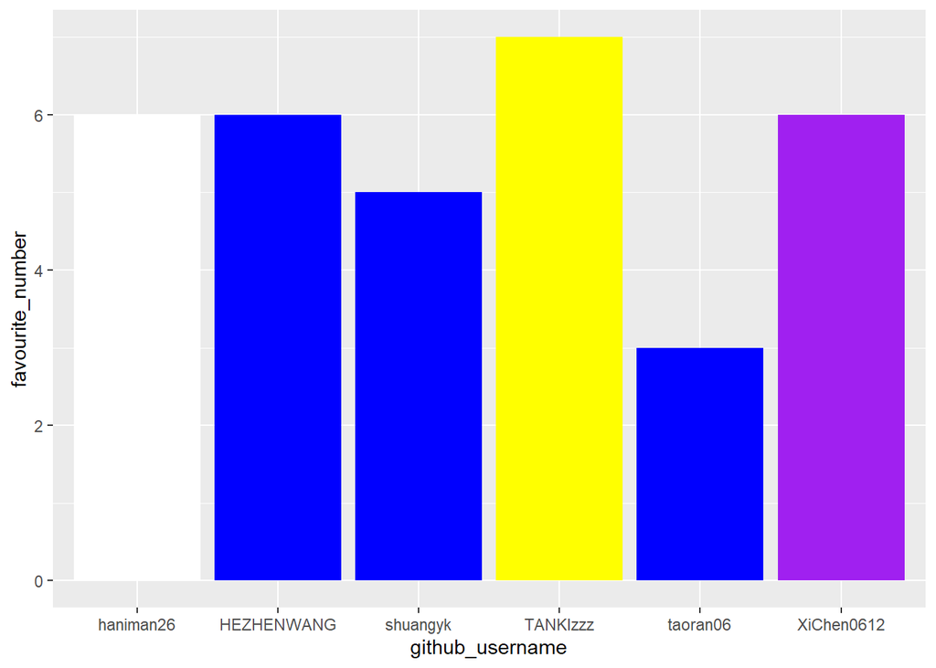

```r
p1 <- ggplot(data = team_data,
             mapping = aes(x = github_username,
                           y = favourite_number,
                           fill = colour),
             ) +
   geom_col() +
   scale_fill_identity()
p1
```

The bar chart shows the favourite number of each team member. Each person’s bar is their favourite colour.

### Exercises 19

Change the text of the plot title and axis labels.

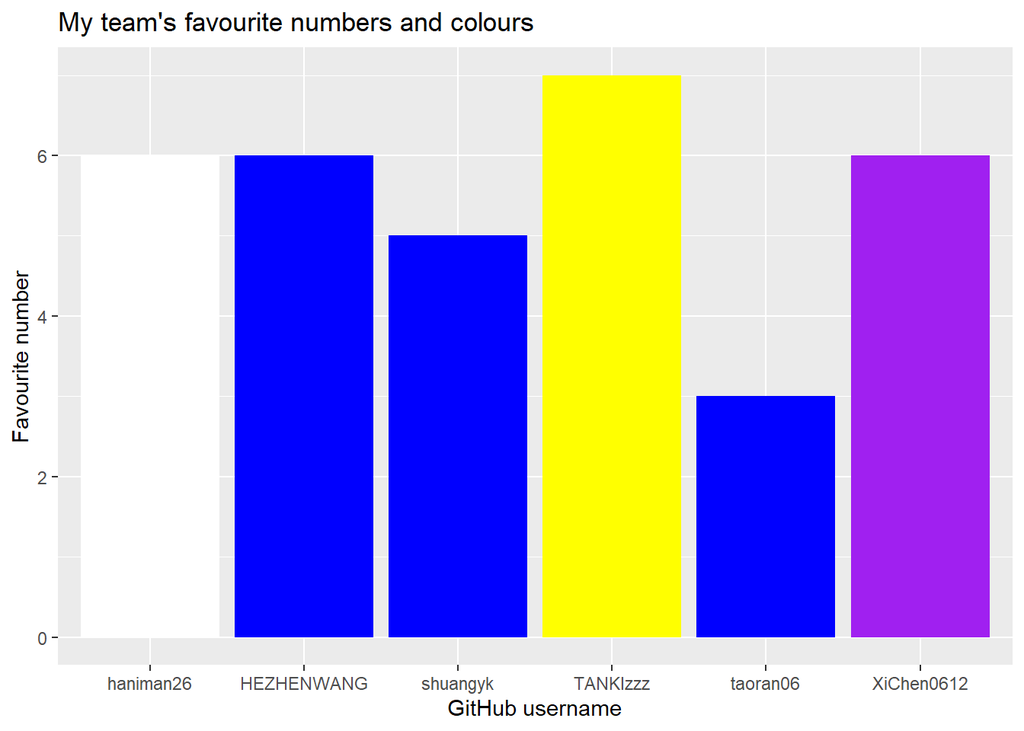

```r
p1 + labs(x = "GitHub username",
          y = "Favourite number",
          title = "My team's favourite numbers and colours")
```

‘labs’ is short for labels, and allows us to add labels to a graph we create.

### Exercise 20

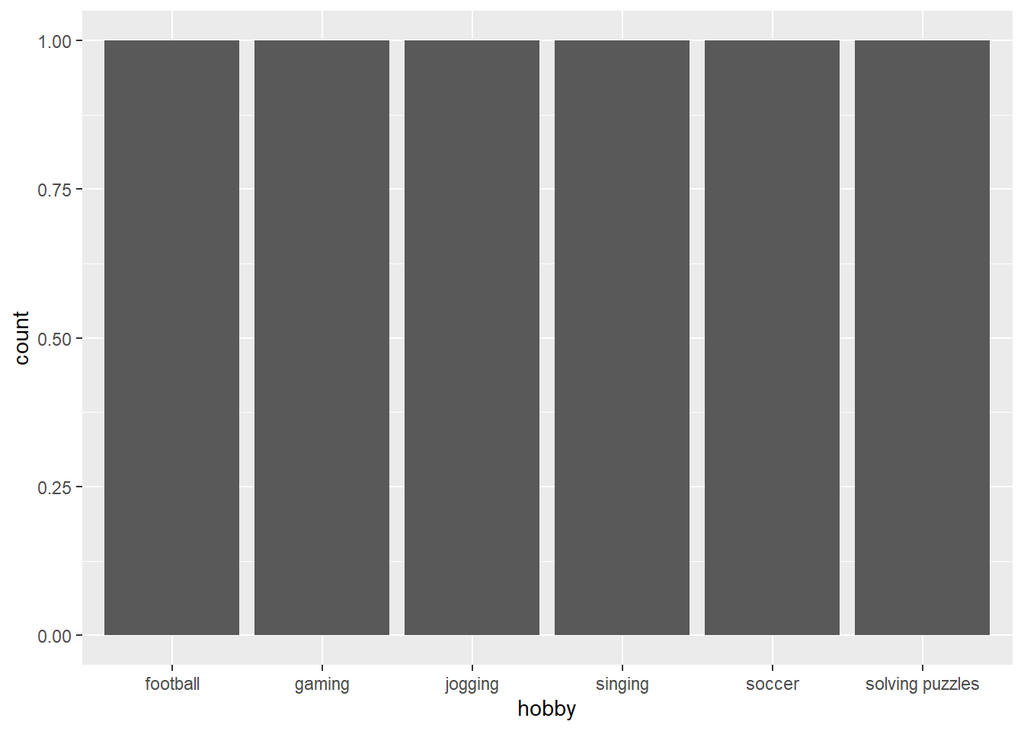

```r
p2 <- ggplot(team_data, aes(x = hobby)) +
  geom_bar()
p2
```

There are lots of different hobbies and there are also lots of people. A large amount of people will have hobbies that are obscure or rare. This means that there will be lots of hobbies with just one person doing them. Also, a hobby could be given a different name, in this example, the same hobby appears twice, once as ‘football’ and the other time as ‘soccer’.

A way we could improve the method of data representation is by using a pie chart and grouping together hobbies with one instance under the ‘miscellaneous’ tag.